# Exercise 1

Roei Aharon, Hila Livnat, Daniel Erez

27 March 2025

```r
# install.packages("ggplot2")
# install.packages("GGally")
# library(ggplot2)
# library(GGally)
```

**Section A – File Reading:**

```r
#Qa
dir_name <- "/Users/danielerez/data"
file_C <- sprintf("%s/%s", "data", "chr1_str_50M_70M.rda")
data_C = load(file_C)
region_line_C <- strsplit(chr1_str_50M_70M, split = "")[[1]]
bin_size <- 2000
regionC_factored = factor(region_line_C, c("A","T","C","G"))
```

```r
# table(region_line_C)
```

```r
# regionA_factored = factor(region_line_A, c("A","T","C","G"))
# regionB_factored = factor(region_line_B, c("A","T","C","G"))
# round(table(regionC_factored), digits = -4) /10^6
```

**Section B – A function that receives a genomic region and calculates the number of occurrences of each base in that region:**

A function that takes a region in the genome and calculates the number of appearances of each base (A, T, C, G) in that region.

```r
#Q b
# Receives region and cell size and summarizes number of bases in each cell
cell_counts = function(region, cell_size = 2000) {
  n = length(region)
  n_cells = ceiling(n / cell_size)

  res = data.frame(
    cell =  integer(n_cells),
    A = integer(n_cells),
    T = integer(n_cells),
    C = integer(n_cells),
    G = integer(n_cells)
  )


  # counting the number of appearances
  for (i in 1:n_cells) {
    start_idx = (i-1) * cell_size + 1
    end_idx = min(i * cell_size, n)
    cell_segment = region[start_idx:end_idx]
    base_counts = table(cell_segment)

    res$cell[i] = i
    res$A[i] <- ifelse("A" %in% names(base_counts), base_counts["A"], 0)
    res$T[i] <- ifelse("T" %in% names(base_counts), base_counts["T"], 0)
    res$C[i] <- ifelse("C" %in% names(base_counts), base_counts["C"], 0)
    res$G[i] <- ifelse("G" %in% names(base_counts), base_counts["G"], 0)
  }
  return (res)
}
```

```r
counts_C <- cell_counts(regionC_factored, cell_size = bin_size)
```

**Section C – In each histogram, you can see the distribution of each of the bases in the chromosome:**

You can see that A and T are relatively close to a normal distribution, while the others look like a normal distribution with a right-hand tail.

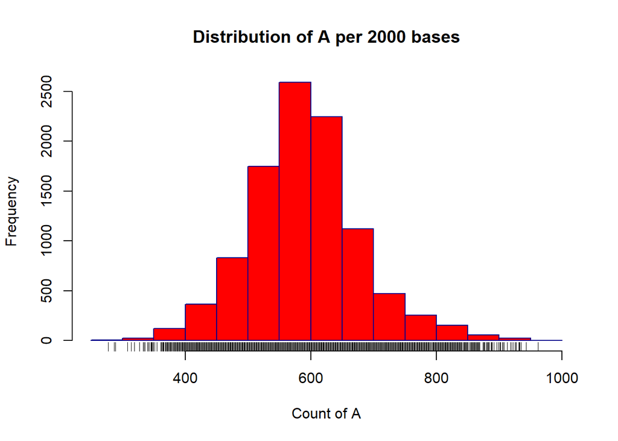

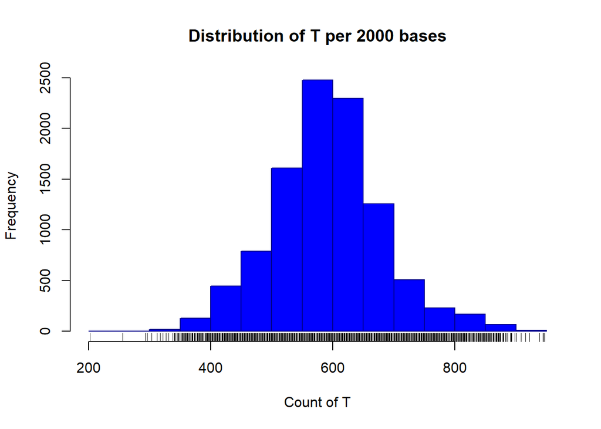

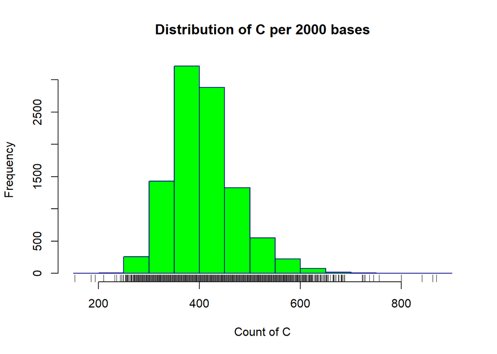

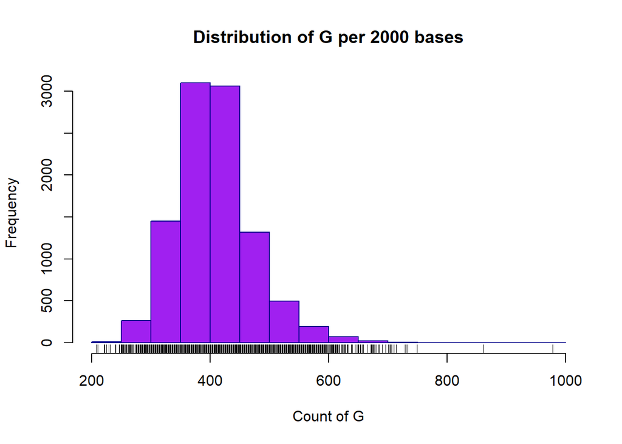

```r
#Q c
# histogram
#create historgram dist for each chromozon
hist_colors <- c("red", "blue", "green", "purple")
chroms <- c("A","T", "C", "G")
for (j in seq_along(chroms)){
  N = length(regionC_factored)
  n_bins = ceiling(N/bin_size)
  C_count = numeric(N/bin_size)
  for (i in 1:n_bins){
    start_bin = 1+ (i-1)*bin_size
    end_bin = i*bin_size
    C_count[i] = sum(regionC_factored[start_bin:end_bin] ==chroms[j])
  }

  hist(C_count,
       main = paste("Distribution of", chroms[j], "per", bin_size, "bases"),
       xlab = paste("Count of", chroms[j]),
       ylab = "Frequency",
       col = hist_colors[j],
       border = "darkblue"
      )
  rug(C_count, color="orange")
}
```

**Section D –**

In the above plots, we see the frequency of specific bases in cells of size 2000 relative to their position on the chromosome. You can observe that the lines follow the same trend line (the dashed black line). There’s a slight increase or decrease around cell 2000, but overall, the trend is consistent across all lines, and the frequency forms a sort of straight line.

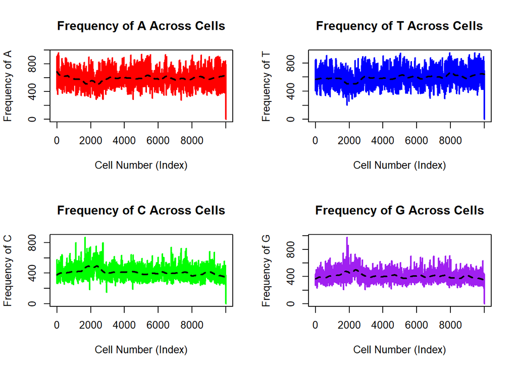

```r
#Q d
# Set up 2x2 plotting area
# ylim_range <- c(0, 1)
par(mfrow = c(2, 2))
#
# # Plot A
# plot(counts_C$cell, counts_C$A/bin_size, type = "l", lty = 1, lwd = 2,
#      col = hist_colors[1],
#      xlab = "Chromosome Position (Cell Index)",
#      ylab = "Frequency",
#      main = "Frequency of A",
#      ylim = ylim_range)
#
# # Plot T
# plot(counts_C$cell, counts_C$T/bin_size, type = "l", lty = 1, lwd = 2,
#      col = hist_colors[2],
#      xlab = "Chromosome Position (Cell Index)",
#      ylab = "Frequency",
#      main = "Frequency of T",
#      ylim = ylim_range)
#
# # Plot C
# plot(counts_C$cell, counts_C$C/bin_size, type = "l", lty = 1, lwd = 2,
#      col = hist_colors[3],
#      xlab = "Chromosome Position (Cell Index)",
#      ylab = "Frequency",
#      main = "Frequency of C",
#      ylim = ylim_range)
#
# # Plot G
# plot(counts_C$cell, counts_C$G/bin_size, type = "l", lty = 1, lwd = 2,
#      col = hist_colors[4],
#      xlab = "Chromosome Position (Cell Index)",
#      ylab = "Frequency",
#      main = "Frequency of G",
#      ylim = ylim_range)
#

# Create boxplot for base frequencies across all cells
# boxplot(counts_C[, c("A", "T", "C", "G")],
#         col = hist_colors,
#         ylab = "Frequency",
#         xlab = "Base",
#         main = "Distribution of Base Frequencies Across Cells")

plot_base_frequency <- function(base, data = counts_C, color = "blue", trend_col = "black") {
  # Check if the base column exists
  if (!(base %in% names(data))) {
    stop(paste("Base", base, "not found in data"))
  }

  # Extract cell positions and base frequencies
  x <- data$cell
  y <- data[[base]]

  # Plot raw frequency data
  plot(x, y, type = "l", lwd = 2,
       col = color,
       xlab = "Cell Number (Index)",
       ylab = paste("Frequency of", base),
       main = paste("Frequency of", base, "Across Cells"))

  # Add loess-smoothed trend line
  trend <- loess(y ~ x, span = 0.1)  # adjust `span` for more/less smoothing
  lines(x, predict(trend), col = trend_col, lwd = 2, lty = 2)
}

for (j in seq_along(chroms)){
  plot_base_frequency(chroms[j], color = hist_colors[j], trend_col = "black")

}
```

**Section E – In the following plots, we can see the frequency for every pair of bases:**